# Module 2 — Somatic Mutations in Wilms Tumor

Exome Sequencing Tutorial: A Real Pediatric Cancer Cohort with maftools

Francesco Cecere** · *Senior Bioinformatic Researcher* · AORN Santobono-Pausilipon IRCCS

05 novembre 2026

# From Module 1

Module 1 turned the reads of **one** person into a list of **germline** variants: the ones inherited from the parents and present in every cell. Cancer adds a second layer: **somatic** mutations, acquired by the tumor cells during life and absent from the rest of the body.

To find them, a tumor exome is sequenced together with a **normal** sample of the same patient (usually blood), and a somatic caller keeps the variants present in the tumor but **not** in the normal. This module starts *after* that step, from the results of the GDC somatic pipeline for the Wilms tumors of the **TARGET** program.

**Plan:** the MAF format → one sample per patient → cohort summary → mutation burden → the genes → TP53 in detail → every tumor and its control.

# Part 1 — The MAF Format

Somatic mutations of a cohort are usually shared as a **MAF** (Mutation Annotation Format) file: a table with one row per mutation, already annotated with gene, consequence and protein change. `data/somatic/` contains, built by `data-prep/build_somatic_data.R` from the GDC Data Portal:

- `TARGET_WT_somatic_mutations.maf.gz`: every open-access somatic mutation from **whole-exome sequencing** of TARGET-WT tumors (GRCh38);
- `TARGET_WT_clinical.tsv`: one row per tumor sample, with the patient’s histology, age, sex and vital status.

```r
maf_table <- read_tsv("data/somatic/TARGET_WT_somatic_mutations.maf.gz",
                      col_types = cols(.default = col_character()))
clinical  <- read_tsv("data/somatic/TARGET_WT_clinical.tsv", show_col_types = FALSE)
```

The MAF columns used in this module (the file has many more).

| column | meaning |
| --- | --- |
| Hugo_Symbol | Gene |
| Chromosome, Start_Position | Where the mutation is |
| Reference_Allele, Tumor_Seq_Allele2 | Normal and mutated base(s) |
| Variant_Classification | Consequence: Missense_Mutation, Nonsense_Mutation, Frame_Shift_Del, Splice_Site… |
| HGVSp_Short | Protein change, e.g. p.R248Q |
| Tumor_Sample_Barcode | Which tumor sample |
| t_alt_count, t_depth | Reads supporting the mutation / total reads in the tumor |

| Hugo_Symbol | Chromosome | Start_Position | Reference_Allele | Tumor_Seq_Allele2 | Variant_Classification | HGVSp_Short | Tumor_Sample_Barcode | t_alt_count | t_depth |
| --- | --- | --- | --- | --- | --- | --- | --- | --- | --- |
| BRINP2 | chr1 | 177257346 | - | G | Frame_Shift_Ins | p.L212Afs*27 | TARGET-50-PAJNNC-01A-01D | 58 | 293 |
| AMZ1 | chr7 | 2709099 | G | A | Missense_Mutation | p.R209Q | TARGET-50-PAJNNC-01A-01D | 53 | 172 |
| CD36 | chr7 | 80661140 | C | - | Frame_Shift_Del | p.I121Sfs*36 | TARGET-50-PAJNNC-01A-01D | 39 | 125 |
| CCDC105 | chr19 | 15011271 | G | A | Missense_Mutation | p.G149E | TARGET-50-PAJNNC-01A-01D | 33 | 61 |
| ATP6V0B | chr1 | 43976837 | G | A | Intron |  | TARGET-50-PAJLWT-01A-01D | 31 | 65 |
| TNRC18 | chr7 | 5371276 | G | - | Frame_Shift_Del | p.D1106Efs*53 | TARGET-50-PAJLWT-01A-01D | 14 | 34 |
| AGK | chr7 | 141652911 | G | T | Missense_Mutation | p.S419I | TARGET-50-PAJLWT-01A-01D | 4 | 32 |
| VPS13B | chr8 | 99871674 | C | T | Missense_Mutation | p.P3933S | TARGET-50-PAJLWT-01A-01D | 23 | 46 |
| OR4C3 | chr11 | 48325129 | G | A | Silent | p.T36= | TARGET-50-PAJLWT-01A-01D | 41 | 95 |
| MN1 | chr22 | 27797847 | - | CTGCTA | In_Frame_Ins | p.S898_S899dup | TARGET-50-PAJLWT-01A-01D | 8 | 19 |

[output cut: 411 more lines]

**How few mutations!** The whole file has 421 mutations for 42 tumor samples, a handful per tumor. Pediatric cancers have far fewer mutations than adult ones: they arise in a few years rather than decades, without the accumulated damage of aging, smoking or UV light. Part 4 puts a number on this.

The **variant allele fraction** (VAF = `t_alt_count / t_depth`) is the fraction of tumor reads carrying the mutation. A heterozygous mutation present in every tumor cell of a pure sample has VAF ≈ 0.5; normal cells mixed into the sample, or a mutation present only in a subclone, lower it.

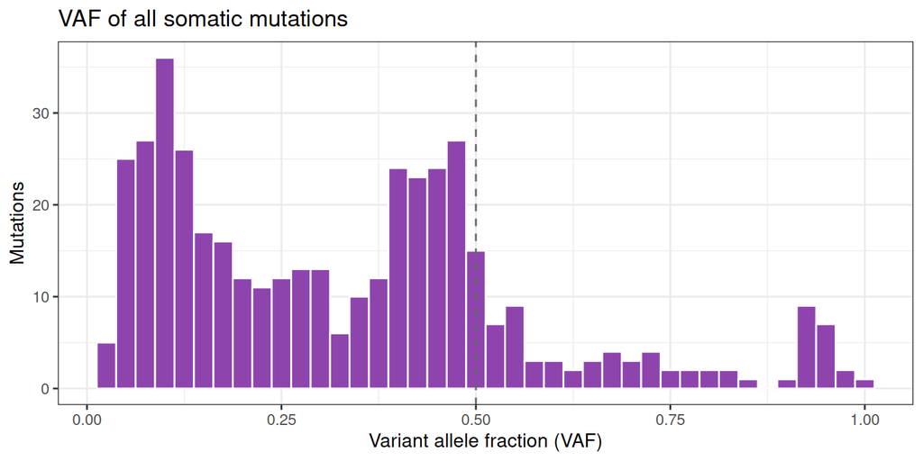

# Part 2 — One Sample per Patient

The TARGET barcode tells us more than the patient: `TARGET-50-PAJLKR-01A-01D` = program, disease code (50 = Wilms tumor), **patient**, **sample type** (01 = primary tumor, 02 = recurrent tumor), vial, portion and analyte (D = DNA).

```r
samples <- clinical %>%
  mutate(sample_type = if_else(str_sub(word(Tumor_Sample_Barcode, 4, sep = "-"), 1, 2) == "01",
                               "Primary", "Recurrent"))

samples_per_patient <- samples %>% group_by(case_submitter_id) %>% filter(n() > 1) %>% ungroup()
```

Patients with more than one sequenced tumor sample.

| case_submitter_id | Tumor_Sample_Barcode | sample_type |
| --- | --- | --- |
| TARGET-50-PAJNGH | TARGET-50-PAJNGH-01A-01D | Primary |
| TARGET-50-PAJNGH | TARGET-50-PAJNGH-02A-01D | Recurrent |
| TARGET-50-PAJNTJ | TARGET-50-PAJNTJ-01A-01D | Primary |
| TARGET-50-PAJNTJ | TARGET-50-PAJNTJ-02A-01D | Recurrent |
| TARGET-50-PAJPDC | TARGET-50-PAJPDC-01A-01D | Primary |
| TARGET-50-PAJPDC | TARGET-50-PAJPDC-02A-01D | Recurrent |
| TARGET-50-PALFME | TARGET-50-PALFME-01A-01D | Primary |
| TARGET-50-PALFME | TARGET-50-PALFME-02A-01D | Recurrent |

Some patients contribute both a **primary** and a **recurrent** tumor. For cohort statistics (“how many *patients* carry a TP53 mutation?”) each patient must count once, otherwise those patients would weigh double. We keep **one sample per patient**: the primary tumor when available.

```r
cohort <- samples %>%
  arrange(case_submitter_id, sample_type != "Primary") %>%
  distinct(case_submitter_id, .keep_all = TRUE)

maf <- read.maf(
  maf          = maf_table %>% filter(Tumor_Sample_Barcode %in% cohort$Tumor_Sample_Barcode),
  clinicalData = cohort,
  verbose      = FALSE
)
maf
```

```
## An object of class  MAF
##                    ID summary  Mean Median
##                <char>  <char> <num>  <num>
##  1:        NCBI_Build  GRCh38    NA     NA
##  2:            Center     BCM    NA     NA
##  3:           Samples      38    NA     NA
##  4:            nGenes     273    NA     NA
##  5:   Frame_Shift_Del      15 0.395    0.0
##  6:   Frame_Shift_Ins       8 0.211    0.0
##  7:      In_Frame_Del       7 0.184    0.0
##  8:      In_Frame_Ins       3 0.079    0.0
##  9: Missense_Mutation     241 6.342    6.0
## 10: Nonsense_Mutation      18 0.474    0.0
## 11:       Splice_Site       6 0.158    0.0
## 12:             total     298 7.842    6.5
```

One sample per patient.

| tumor samples in the MAF | patients analyzed |
| --- | --- |
| 42 | 38 |

# Part 3 — Cohort Summary

`plotmafSummary()` gives the overview of a cohort in one figure: mutations per sample, their types, and the most frequently mutated genes.

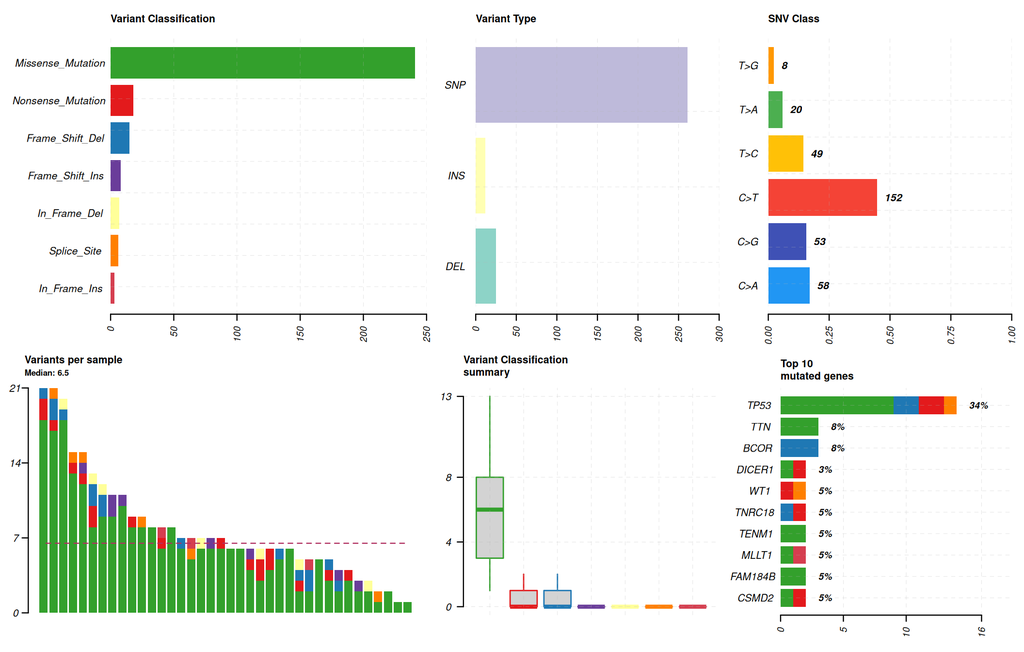

**How to read it.** *Variant Classification*: missense mutations dominate, as in almost every cancer. *Variants per sample*: the red line is the median, a few mutations per exome. *Top 10 mutated genes*: the percentage is the fraction of patients with at least one mutation in that gene.

# Part 4 — Tumor Mutational Burden

**Tumor mutational burden (TMB)** is the number of somatic mutations per **megabase** of sequenced DNA. It matters clinically: tumors with very high TMB (e.g. melanoma, lung cancer in smokers) respond better to immunotherapy, because more mutations mean more abnormal proteins the immune system can recognize.

```r
# Exome capture kits target roughly 35-50 Mb; maftools needs the size to turn counts into a rate.
tmb_table <- tmb(maf, captureSize = 50, logScale = TRUE)
```

```
## --Possible FLAGS among top ten genes:
##   TTN
## -Processing clinical data
```

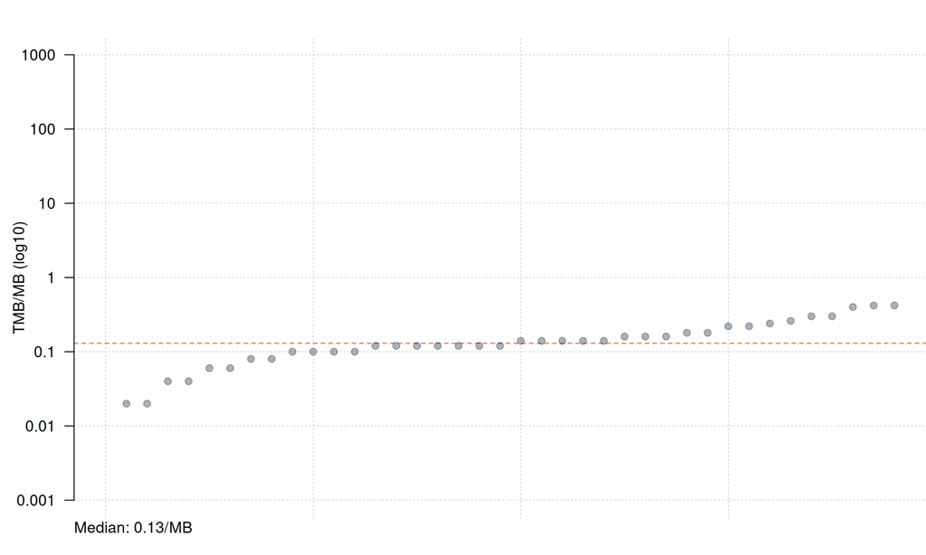

TMB in TARGET-WT (mutations per Mb, assuming a 50 Mb exome).

| patients | median_mutations | median_TMB_per_Mb | max_TMB_per_Mb |
| --- | --- | --- | --- |
| 38 | 6.5 | 0.13 | 0.42 |

How does that compare with adult cancers? `tcgaCompare()` places our cohort among the 33 adult cancer types of **TCGA** (data bundled with maftools):

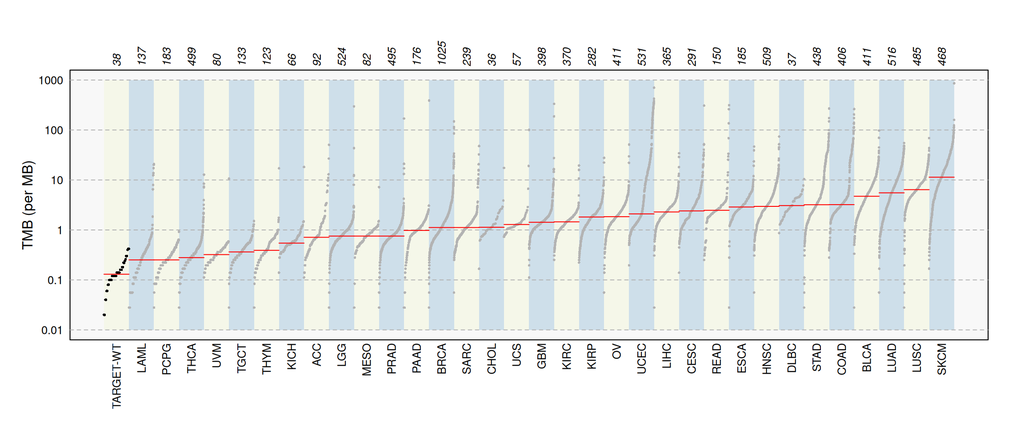

**Wilms tumor sits at the far left, below every adult cancer type**, even the lowest-burden ones (acute myeloid leukemia, pheochromocytoma, thyroid cancer), and roughly 80 times below melanoma. Low TMB is typical of pediatric cancers, which are driven by a few key genetic events (or by epigenetic changes, such as the 11p15.5 imprinting defects of Module 1’s region) rather than by thousands of mutations. It is also one reason immunotherapy has so far had limited success in most childhood solid tumors.

## Transitions and Transversions

The kind of base change carries a memory of what caused it. `titv()` classifies every SNV into the six possible substitution types.

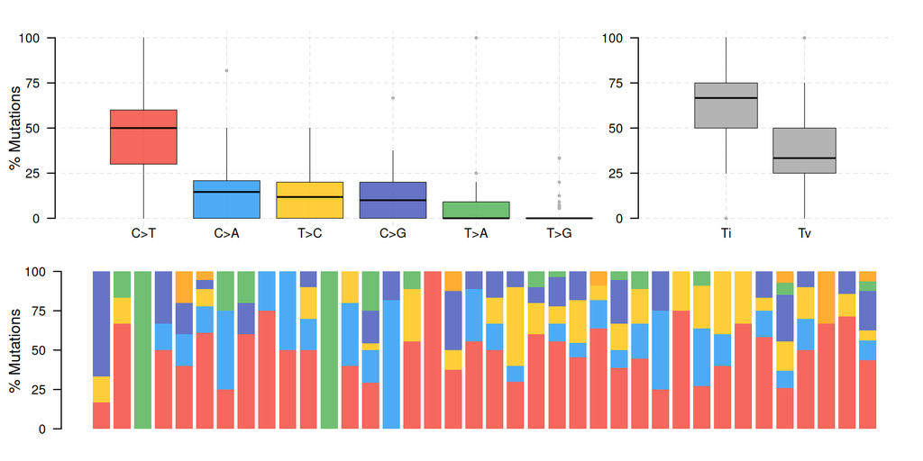

**C>T dominates.** The most frequent change in almost every tumor is C>T, largely due to the spontaneous deamination of methylated cytosines (5-methylcytosine → thymine), a “clock-like” process that accumulates slowly with every cell division. Specific exposures leave different marks (e.g. C>A for tobacco smoke, C>T at dipyrimidines for UV light); a formal **mutational signature** analysis needs many more mutations per tumor than Wilms tumors carry.

# Part 5 — The Mutated Genes

An **oncoplot** is the standard picture of a cancer cohort: one column per patient, one row per gene, colored by the type of mutation. The bar on top shows each patient’s number of mutations.

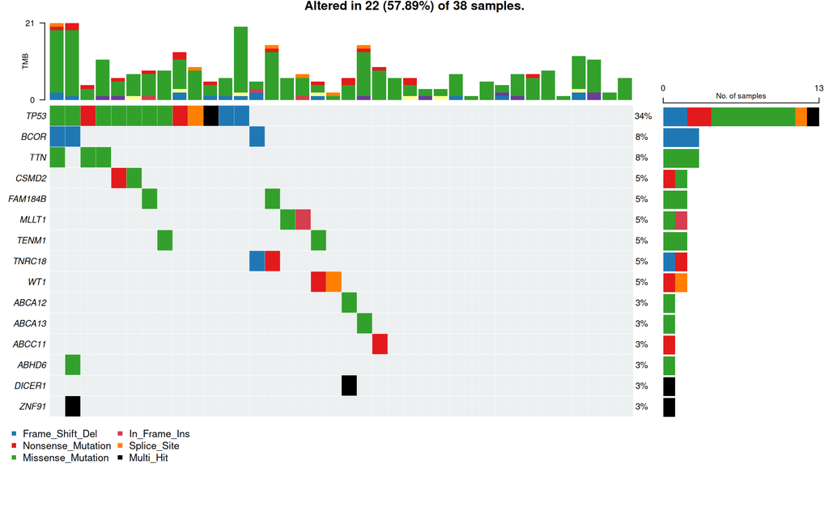

**Frequent is not the same as important.** `TP53` is a real cancer gene. But `TTN` (titin, the largest human protein) and other very long genes appear near the top of almost every cancer cohort simply because they offer the biggest target to random mutations. Telling **drivers** (mutations that give the cell an advantage) from **passengers** (neutral hitchhikers) needs more than counting: prior knowledge, recurrence at the same position, or statistical models of the background mutation rate.

## Known Wilms Tumor Drivers

Wilms tumor has a well-studied set of driver genes, falling into a few pathways: the **WT1/β-catenin** pathway (`WT1`, `CTNNB1`, `AMER1`), **microRNA processing** (`DROSHA`, `DGCR8`, `DICER1`), **kidney development** transcription factors (`SIX1`, `SIX2`), **chromatin and transcription regulators** (`MLLT1`, `BCOR`, `ARID1A`, `CDC73`), and `TP53`.

```r
wilms_drivers <- c("TP53", "WT1", "CTNNB1", "AMER1", "DROSHA", "DGCR8", "DICER1",
                   "SIX1", "SIX2", "MYCN", "MLLT1", "BCOR", "ARID1A", "CDC73")
drivers_found <- intersect(wilms_drivers, getGeneSummary(maf)$Hugo_Symbol)
```

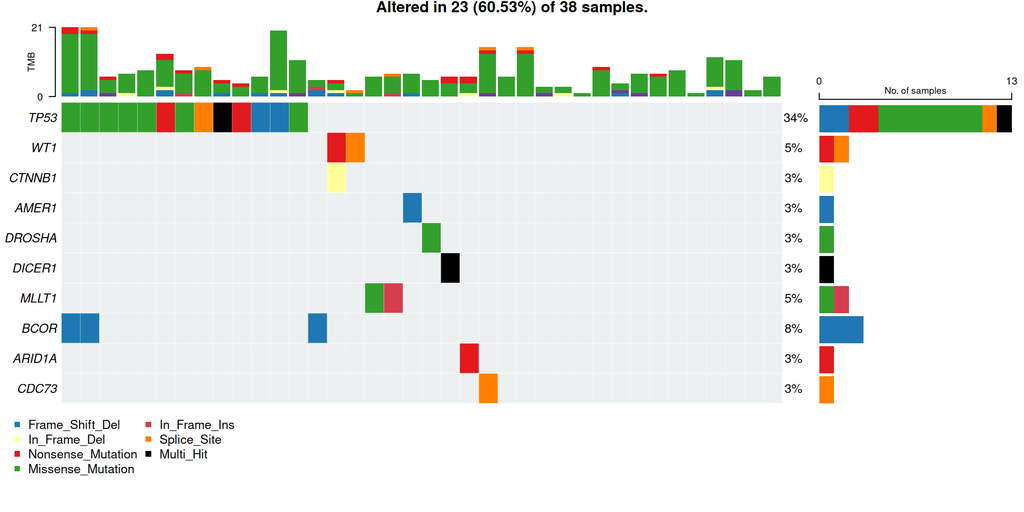